# Simulacro Examen 2

## Examen 1

1. Leer el fichero de trabajo y describir su estructura (número de variables y tipo)

```r
datos = read.table("../datos/datos_salarios.txt", sep=" ", header=T)
str(datos) # Variables y tipos
```

```
## 'data.frame':    3000 obs. of  10 variables:
##  $ ano.inicio     : int  2006 2004 2003 2003 2005 2008 2009 2008 2006 2004 ...
##  $ edad           : int  18 24 45 43 50 54 44 30 41 52 ...
##  $ estado.civil   : Factor w/ 5 levels "casado","divorciado",..: 4 4 1 1 2 1 1 4 4 1 ...
##  $ raza           : Factor w/ 4 levels "asiatica","blanca",..: 2 2 2 1 2 2 4 1 3 2 ...
##  $ nivel.educacion: Factor w/ 5 levels "Algun Curso Universidad",..: 5 3 1 3 2 3 1 1 1 2 ...
##  $ tipo.trabajo   : Factor w/ 2 levels "Industrial","Servicios": 1 2 1 2 2 2 1 2 2 2 ...
##  $ salud          : Factor w/ 2 levels "buena","muy buena": 1 2 1 2 1 2 2 1 2 2 ...
##  $ seguro.medico  : Factor w/ 2 levels "no","si": 1 1 2 2 2 2 2 2 2 2 ...
##  $ log.salario    : num  4.32 4.26 4.88 5.04 4.32 ...
##  $ salario        : num  75 70.5 131 154.7 75 ...
```

```r
names(datos) # Nombres de las variables
```

```
##  [1] "ano.inicio"      "edad"            "estado.civil"
##  [4] "raza"            "nivel.educacion" "tipo.trabajo"
##  [7] "salud"           "seguro.medico"   "log.salario"
## [10] "salario"
```

2. Representar la variable salario mediante un diagrama de cajas

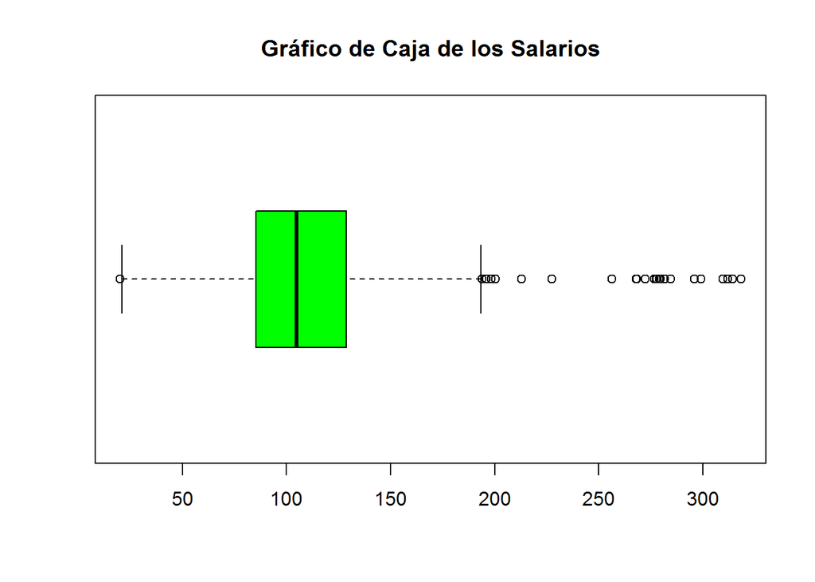

```r
salarios = datos['salario'] # datos$salario o attach(datos) y luego salario
boxplot(salarios,col="green",main="Gráfico de Caja de los Salarios", horizontal = T)
```

3. representar un diagrama de caja de la variable salario clasificado por tipo de trabajo (Sector industrial y sector servicios), qué sector tiene salario medio mayor

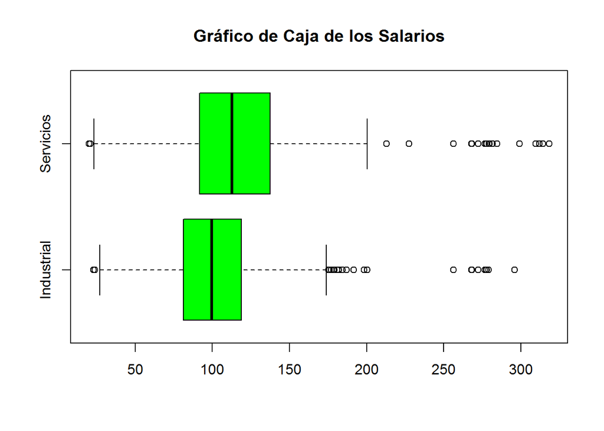

```r
tabla = table(datos$tipo.trabajo) #Cuento de cada tipo
# Comparacion de campo Salario en base al campo trabajo.
boxplot(datos$salario ~ datos$tipo.trabajo,col="green",main="Gráfico de Caja de los Salarios", horizontal = T)
```

4. Media y varianza de la variable salario

```r
salario = datos$salario
n = length(salario)
media = mean(salario)
varianza= var(salario)*((n-1)/n)  #varianza
```

5. Tabla de frecuencias de la variable razas, cuantos de asiaticos

```r
raza = datos$raza
absoluta = table(raza)
relativa = absoluta/length(raza)
tabla=cbind(relativa, absoluta)
tabla
```

```
##            relativa absoluta
## asiatica 0.06333333      190
## blanca   0.82666667     2480
## negra    0.09766667      293
## otra     0.01233333       37
```

6. Representar gráficamente la variable raza utilizando dos tipos de gráfico distintos

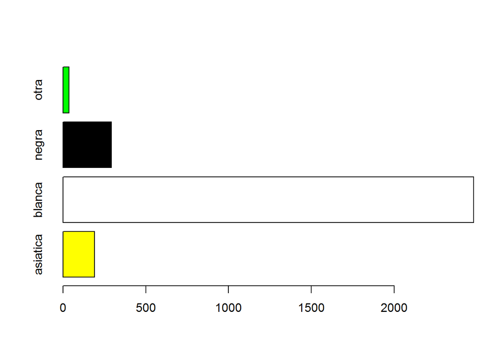

```r
raza = datos$raza
absoluta = table(raza)
# Gráfico de barras
barplot(absoluta,horiz=TRUE,col=c("yellow","white","black", "green"))
```